# Project: No-show appointments

- Introduction
- Data Wrangling
- Exploratory Data Analysis
- Conclusions

## Introduction

> In this project , This dataset collects information from 100k medical appointments in Brazil and is focused on the question of whether or not patients show up for their appointment.

> This data sets contains recordes whether patients miss appointments , attributes of patients and information about appointments (original source on Kaggle)

### Question

> - Are no-show appointments associated with a certain gender?
> - Who in terms of age misses more appointments?
> - Are chronic illnesses like hypertension and diabetes affecting patient's absences?
> - Is alcoholism a prominent factor in patient's absences?
> - Do SMS reminders decrease the number of absences?

```python
#import libraries
import numpy as np
import pandas as pd
import seaborn as sns
import matplotlib.pyplot as plt
% matplotlib inline
```

## Data Wrangling

### General Properties

```python
#load data
df = pd.read_csv("noshowapp.csv")
df.head()
```

|  | PatientId | AppointmentID | Gender | ScheduledDay | AppointmentDay | Age | Neighbourhood | Scholarship | Hipertension | Diabetes | Alcoholism | Handcap | SMS_received | No-show |
| --- | --- | --- | --- | --- | --- | --- | --- | --- | --- | --- | --- | --- | --- | --- |
| 0 | 2.987250e+13 | 5642903 | F | 2016-04-29T18:38:08Z | 2016-04-29T00:00:00Z | 62 | JARDIM DA PENHA | 0 | 1 | 0 | 0 | 0 | 0 | No |
| 1 | 5.589978e+14 | 5642503 | M | 2016-04-29T16:08:27Z | 2016-04-29T00:00:00Z | 56 | JARDIM DA PENHA | 0 | 0 | 0 | 0 | 0 | 0 | No |
| 2 | 4.262962e+12 | 5642549 | F | 2016-04-29T16:19:04Z | 2016-04-29T00:00:00Z | 62 | MATA DA PRAIA | 0 | 0 | 0 | 0 | 0 | 0 | No |
| 3 | 8.679512e+11 | 5642828 | F | 2016-04-29T17:29:31Z | 2016-04-29T00:00:00Z | 8 | PONTAL DE CAMBURI | 0 | 0 | 0 | 0 | 0 | 0 | No |
| 4 | 8.841186e+12 | 5642494 | F | 2016-04-29T16:07:23Z | 2016-04-29T00:00:00Z | 56 | JARDIM DA PENHA | 0 | 1 | 1 | 0 | 0 | 0 | No |

```python
lst_col=['PatientId','AppointmentID','Gender','ScheduledDay','AppointmentDay','Age','Neighbourhood','Scholarship','Hypertension','Diabetes','Alcoholism','Handicap','SMS_received','No-show']
df.columns=lst_col
df.columns
```

```
Index(['PatientId', 'AppointmentID', 'Gender', 'ScheduledDay',
       'AppointmentDay', 'Age', 'Neighbourhood', 'Scholarship', 'Hypertension',
       'Diabetes', 'Alcoholism', 'Handicap', 'SMS_received', 'No-show'],
      dtype='object')
```

## Drop useless data

```python
df.drop(['PatientId','AppointmentID'],axis=1,inplace=True)
```

```python
df.info()
```

```
<class 'pandas.core.frame.DataFrame'>
RangeIndex: 110527 entries, 0 to 110526
Data columns (total 12 columns):
Gender            110527 non-null object
ScheduledDay      110527 non-null object
AppointmentDay    110527 non-null object
Age               110527 non-null int64
Neighbourhood     110527 non-null object
Scholarship       110527 non-null int64
Hypertension      110527 non-null int64
Diabetes          110527 non-null int64
Alcoholism        110527 non-null int64
Handicap          110527 non-null int64
SMS_received      110527 non-null int64
No-show           110527 non-null object
dtypes: int64(7), object(5)
memory usage: 10.1+ MB
```

```python
df['No-show'].unique()
```

```
array(['No', 'Yes'], dtype=object)
```

```python
#Takes a string which is either a yes or no and returns an int
def parse_int(i):
    if i == 'No':
        return 0
    if i == 'Yes':
        return 1
```

```python
df['No-show']=df['No-show'].map(lambda x : parse_int(x))
df['No-show'].unique()
```

```
array([0, 1])
```

```python
df.describe()
```

|  | Age | Scholarship | Hypertension | Diabetes | Alcoholism | Handicap | SMS_received | No-show |
| --- | --- | --- | --- | --- | --- | --- | --- | --- |
| count | 110527.000000 | 110527.000000 | 110527.000000 | 110527.000000 | 110527.000000 | 110527.000000 | 110527.000000 | 110527.000000 |
| mean | 37.088874 | 0.098266 | 0.197246 | 0.071865 | 0.030400 | 0.022248 | 0.321026 | 0.201933 |
| std | 23.110205 | 0.297675 | 0.397921 | 0.258265 | 0.171686 | 0.161543 | 0.466873 | 0.401444 |
| min | -1.000000 | 0.000000 | 0.000000 | 0.000000 | 0.000000 | 0.000000 | 0.000000 | 0.000000 |
| 25% | 18.000000 | 0.000000 | 0.000000 | 0.000000 | 0.000000 | 0.000000 | 0.000000 | 0.000000 |
| 50% | 37.000000 | 0.000000 | 0.000000 | 0.000000 | 0.000000 | 0.000000 | 0.000000 | 0.000000 |
| 75% | 55.000000 | 0.000000 | 0.000000 | 0.000000 | 0.000000 | 0.000000 | 1.000000 | 0.000000 |
| max | 115.000000 | 1.000000 | 1.000000 | 1.000000 | 1.000000 | 4.000000 | 1.000000 | 1.000000 |

```python
df[df['Age'] <= 0].head()
```

|  | Gender | ScheduledDay | AppointmentDay | Age | Neighbourhood | Scholarship | Hypertension | Diabetes | Alcoholism | Handicap | SMS_received | No-show |
| --- | --- | --- | --- | --- | --- | --- | --- | --- | --- | --- | --- | --- |
| 59 | F | 2016-04-29T08:08:43Z | 2016-04-29T00:00:00Z | 0 | CONQUISTA | 0 | 0 | 0 | 0 | 0 | 0 | 0 |
| 63 | M | 2016-04-27T10:46:12Z | 2016-04-29T00:00:00Z | 0 | SÃO BENEDITO | 0 | 0 | 0 | 0 | 0 | 0 | 0 |
| 64 | M | 2016-04-25T13:28:21Z | 2016-04-29T00:00:00Z | 0 | ILHA DAS CAIEIRAS | 0 | 0 | 0 | 0 | 0 | 1 | 0 |
| 65 | M | 2016-04-27T10:48:50Z | 2016-04-29T00:00:00Z | 0 | CONQUISTA | 0 | 0 | 0 | 0 | 0 | 0 | 0 |
| 67 | F | 2016-04-29T08:53:02Z | 2016-04-29T00:00:00Z | 0 | NOVA PALESTINA | 0 | 0 | 0 | 0 | 0 | 0 | 0 |

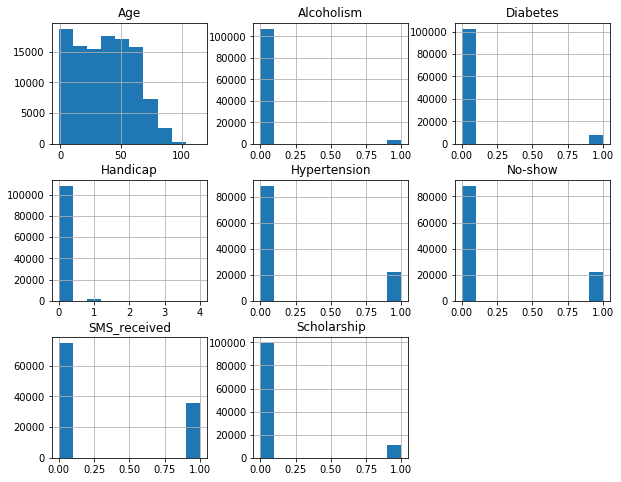

```python
df.hist(figsize=(10,8));
```

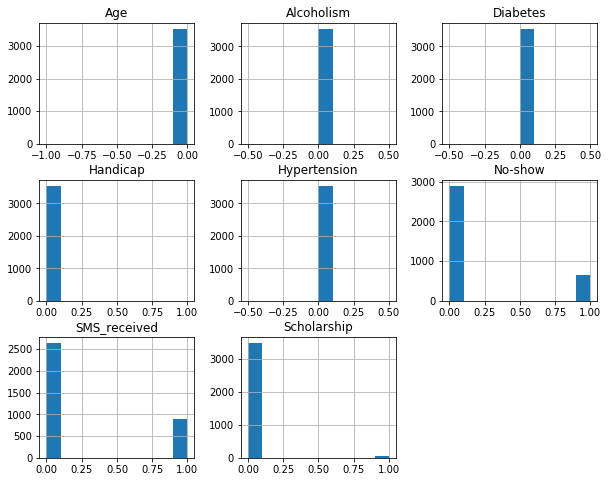

```python
df[df.Age<=0].hist(figsize=(10,8));
```

```python
lst=df[df.Age<=0].index
df.drop(lst,inplace=True)
```

```python
df.describe()
```

|  | Age | Scholarship | Hypertension | Diabetes | Alcoholism | Handicap | SMS_received | No-show |
| --- | --- | --- | --- | --- | --- | --- | --- | --- |
| count | 106987.000000 | 106987.000000 | 106987.000000 | 106987.000000 | 106987.000000 | 106987.000000 | 106987.000000 | 106987.000000 |
| mean | 38.316085 | 0.101031 | 0.203772 | 0.074243 | 0.031406 | 0.022975 | 0.323264 | 0.202641 |
| std | 22.466214 | 0.301371 | 0.402804 | 0.262167 | 0.174412 | 0.164115 | 0.467725 | 0.401969 |
| min | 1.000000 | 0.000000 | 0.000000 | 0.000000 | 0.000000 | 0.000000 | 0.000000 | 0.000000 |
| 25% | 19.000000 | 0.000000 | 0.000000 | 0.000000 | 0.000000 | 0.000000 | 0.000000 | 0.000000 |
| 50% | 38.000000 | 0.000000 | 0.000000 | 0.000000 | 0.000000 | 0.000000 | 0.000000 | 0.000000 |
| 75% | 56.000000 | 0.000000 | 0.000000 | 0.000000 | 0.000000 | 0.000000 | 1.000000 | 0.000000 |
| max | 115.000000 | 1.000000 | 1.000000 | 1.000000 | 1.000000 | 4.000000 | 1.000000 | 1.000000 |

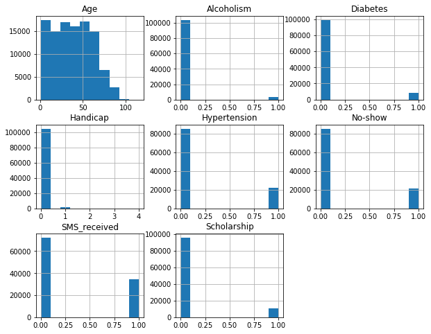

```python
df.hist(figsize=(10,8));
```